# Practical Bayesian Modeling with Stan and brms

Author

Masatoshi Katabuchi

Published

November 3, 2025

# 1 Docker (optional)

Run this on your terminal to start an RStudio Server with all the necessary packages installed.

```
# run in afec-bayes-2025 directory
docker run -d -p 8787:8787 \
  -e PASSWORD=123456  \
  -v $(pwd):/home/rstudio/workspace \
  mattocci/afec-bayes:prod
```

Access `127.0.0.1:8787` and log in with the username `rstudio` and the password `123456` (or your own password).

# 2 renv settings (Optional)

Comment out the following lines in `.Rprofile` if you are not using `renv`.

```bash
# source("renv/activate.R")
# Sys.setenv(RENV_DOWNLOAD_METHOD = "curl")
# options(renv.install.staged = FALSE)
# renv::settings$use.cache(TRUE)
# Sys.setenv(RENV_INSTALL_PAK_ENABLED = "TRUE")
```

# 3 Setup

```r
library(brms)
library(cmdstanr)
library(tidyverse)
library(bayesplot)
library(patchwork)
cmdstanr::cmdstan_path()
```

```
[1] "/home/rstudio/.cmdstan/cmdstan-2.37.0"
```

```r
my_theme <- theme_bw() + theme(
    axis.text = element_text(size = 14),
    strip.text = element_text(size = 14)
  )

theme_set(my_theme)
```

# 4 Normal model

Leaf mass per area (LMA) is an important trait that reflects plant strategies. LMA for interspecific data often shows a log-normal distribution.

$$\text{log}(y_i) \sim N(\mu, \sigma)$$

**Q:** What are the mean ($\mu$) and standard deviation ($\sigma$) of log LMA?

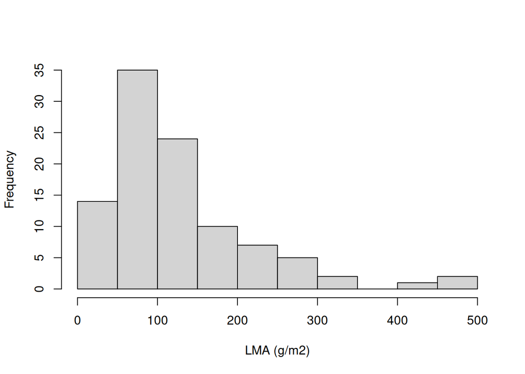

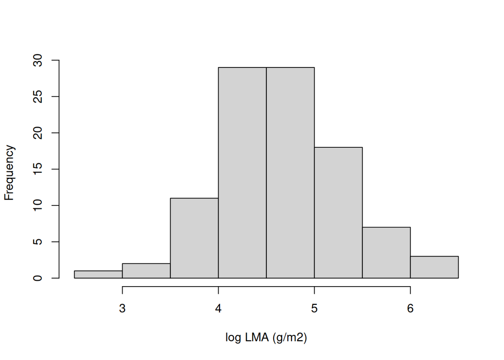

## 4.1 Dummy data

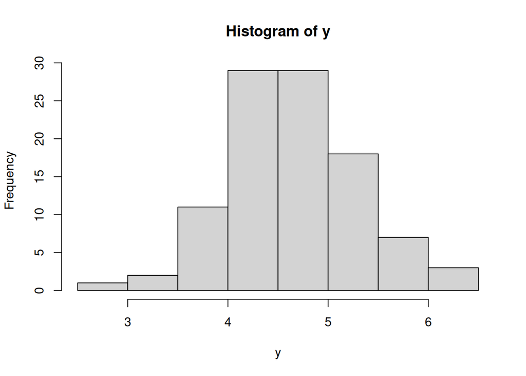

```r
set.seed(123)
n <- 100
mu <- 4.6
sigma <- 0.7
y <- rnorm(n, mean = mu, sd = sigma)

hist(y)
```

`cmdstan` uses list format for data input.

```r
normal_list <- list(
  y = y,
  N = length(y)
)
```

`brms` uses dataframe (tibble) format for data input like `lme4::lmer` and `stats::glm`.

```r
normal_df <- tibble(
  y = y,
  N = length(y)
)
```

## 4.2 CmdStan

We need to write and save Stan programs (.stan files).

`stan/normal.stan`

```stan
 // observed data
data {
  int<lower=0> N;
  vector[N] y;
}

// parameters to be estimated
parameters {
  real mu;
  real<lower=0> sigma;
}

model {
  // likelihood
  y ~ normal(mu, sigma);
  // priors
  mu ~ normal(0, 10);
  sigma ~ cauchy(0, 2.5);
}
```

`stan/normal_vague.stan`

```stan
 data {
  int<lower=0> N;
  vector[N] y;
}

parameters {
  real mu;
  real<lower=0> sigma;
}

model {
  y ~ normal(mu, sigma);
  mu ~ normal(0, 1e+4); // Vague prior for mu
  sigma ~ normal(0, 1e+4); // Vague prior for sigma
}
```

These commands compile the models, translating Stan code to C++ and then into machine-executable files. This takes a while (about 20 secs to 1 min) the first time only.

```r
normal_mod <- cmdstan_model("stan/normal.stan")
normal_vague_mod <- cmdstan_model("stan/normal_vague.stan")
```

```r
# Persist CSV outputs to avoid /tmp cleanup during render
normal_out_dir <- file.path("assets", "cmdstan", "normal")
if (!dir.exists(normal_out_dir)) dir.create(normal_out_dir, recursive = TRUE)

normal_fit <- normal_mod$sample(
  data = normal_list,
  seed = 123,
  chains = 4,
  parallel_chains = 4,
  iter_warmup = 1000,  # number of warmup iterations
  iter_sampling = 1000, # number of sampling iterations
  refresh = 500,        # print update every 500 iters
  output_dir = normal_out_dir
)
```

```
Running MCMC with 4 parallel chains...

Chain 1 Iteration:    1 / 2000 [  0%]  (Warmup)
Chain 1 Iteration:  500 / 2000 [ 25%]  (Warmup)
Chain 1 Iteration: 1000 / 2000 [ 50%]  (Warmup)
Chain 1 Iteration: 1001 / 2000 [ 50%]  (Sampling)
Chain 1 Iteration: 1500 / 2000 [ 75%]  (Sampling)
Chain 1 Iteration: 2000 / 2000 [100%]  (Sampling)
```

[output not shown]

[output not shown]

[output not shown]

[output not shown]

```
Chain 1
```

```
Chain 2 Iteration:    1 / 2000 [  0%]  (Warmup)
Chain 2 Iteration:  500 / 2000 [ 25%]  (Warmup)
Chain 2 Iteration: 1000 / 2000 [ 50%]  (Warmup)
Chain 2 Iteration: 1001 / 2000 [ 50%]  (Sampling)
Chain 2 Iteration: 1500 / 2000 [ 75%]  (Sampling)
Chain 2 Iteration: 2000 / 2000 [100%]  (Sampling)
Chain 3 Iteration:    1 / 2000 [  0%]  (Warmup)
Chain 3 Iteration:  500 / 2000 [ 25%]  (Warmup)
Chain 3 Iteration: 1000 / 2000 [ 50%]  (Warmup)
Chain 3 Iteration: 1001 / 2000 [ 50%]  (Sampling)
Chain 3 Iteration: 1500 / 2000 [ 75%]  (Sampling)
Chain 3 Iteration: 2000 / 2000 [100%]  (Sampling)
Chain 4 Iteration:    1 / 2000 [  0%]  (Warmup)
Chain 4 Iteration:  500 / 2000 [ 25%]  (Warmup)
Chain 4 Iteration: 1000 / 2000 [ 50%]  (Warmup)
Chain 4 Iteration: 1001 / 2000 [ 50%]  (Sampling)
Chain 4 Iteration: 1500 / 2000 [ 75%]  (Sampling)
Chain 4 Iteration: 2000 / 2000 [100%]  (Sampling)
Chain 1 finished in 0.0 seconds.
Chain 2 finished in 0.0 seconds.
Chain 3 finished in 0.0 seconds.
Chain 4 finished in 0.0 seconds.

All 4 chains finished successfully.
Mean chain execution time: 0.0 seconds.
Total execution time: 0.3 seconds.
```

We don’t have to recompile the model when we want to change the number of iterations, chains, or data.

```r
normal_vague_fit <- normal_vague_mod$sample(
  data = normal_list,
  seed = 123,
  chains = 4,
  parallel_chains = 4,
  refresh = 500 # print update every 500 iters
)
```

[output not shown]

### 4.2.1 Summary

We use this output when writing manuscripts and for model diagnostics.

```r
normal_fit$summary()
```

```
# A tibble: 3 × 10
  variable   mean median     sd    mad     q5    q95  rhat ess_bulk ess_tail
  <chr>     <dbl>  <dbl>  <dbl>  <dbl>  <dbl>  <dbl> <dbl>    <dbl>    <dbl>
1 lp__     -6.35  -6.04  0.997  0.731  -8.36  -5.38   1.00    1801.    2192.
2 mu        4.66   4.66  0.0657 0.0661  4.56   4.77   1.00    3300.    2446.
3 sigma     0.648  0.646 0.0466 0.0449  0.577  0.730  1.00    3181.    2516.
```

- `lp__`: log posterior.
  - $\text{log}\; p(\theta \mid \text{data}) \propto \text{log}\; p(\text{data} \mid \theta) + \text{log}\; p(\theta)$
- `rhat` (Gelman-Rubin statistic): should be close to 1.
  - Measures the convergence of the chains.
  - `rhat` > 1.1: Definitely bad.
  - 1.01 < `rhat` < 1.1: Suspicious.
  - `rhat` <= 1.01: Good.
- `ess_bulk` and `ess_tail`: Effective sample size for bulk and tail of the posterior distribution.
  - `ess_bulk`: sampling efficiency for the bulk posteriors (e.g., mean, SD).
  - `ess_tail`: sampling efficiency for the tails (e.g., quantiles like 2.5%, 97.5%).
  - `ess_bulk`, `ess_tail` > 400: Good.

### 4.2.2 Draws (posterior samples)

For each parameter, we have 1000 iterations $\times$ 4 chains = 4000 posteriors. We use this for visualization and diagnostics.

```r
normal_fit$draws()
```

```
# A draws_array: 1000 iterations, 4 chains, and 3 variables
, , variable = lp__

         chain
iteration    1    2    3    4
        1 -7.9 -5.5 -6.7 -6.2
        2 -7.6 -5.4 -8.9 -6.8
        3 -6.7 -5.3 -6.4 -8.3
        4 -6.1 -5.6 -5.9 -6.7
        5 -7.8 -5.6 -6.3 -7.3

, , variable = mu

         chain
iteration   1   2   3   4
        1 4.6 4.6 4.6 4.7
        2 4.6 4.7 4.8 4.7
        3 4.6 4.7 4.7 4.8
        4 4.6 4.7 4.6 4.7
        5 4.8 4.7 4.7 4.7

, , variable = sigma

         chain
iteration    1    2    3    4
        1 0.75 0.63 0.72 0.65
        2 0.57 0.65 0.59 0.57
        3 0.69 0.64 0.61 0.57
        4 0.64 0.62 0.66 0.58
        5 0.65 0.62 0.70 0.58

# ... with 995 more iterations
```

Trace plots for diagnosing convergence and mixing of the chains.

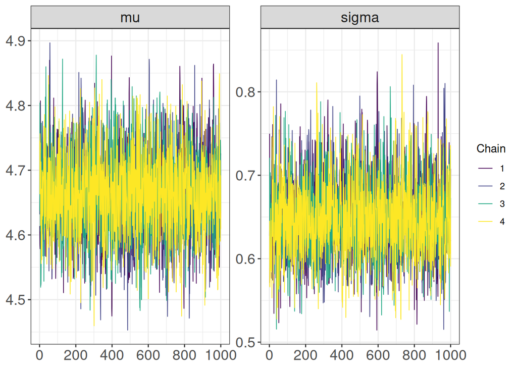

```r
normal_draws <- as_draws_df(normal_fit$draws())

color_scheme_set("viridis")
mcmc_trace(normal_draws, pars = c("mu", "sigma"))
```

Histograms of the posterior distributions of the parameters.

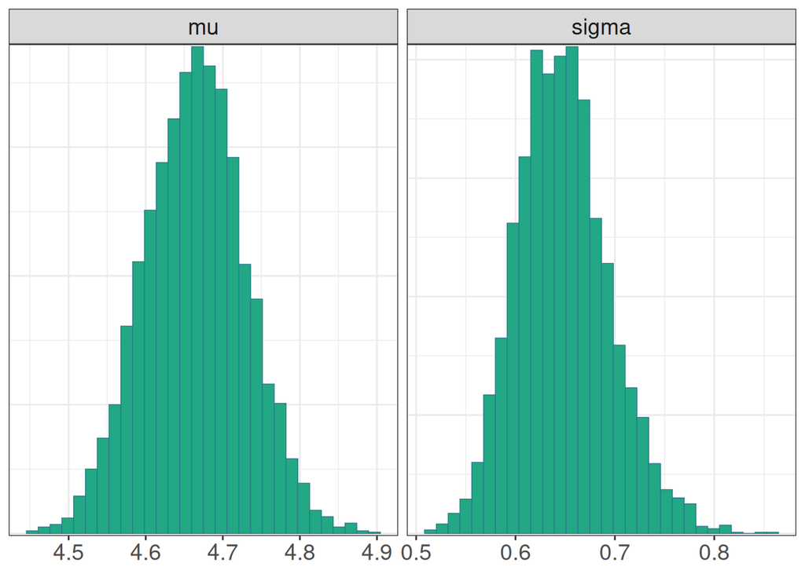

```r
mcmc_hist(normal_draws, pars = c("mu", "sigma"))
```

### 4.2.3 Diagnostic summary

```r
normal_fit$diagnostic_summary()
```

```
$num_divergent
[1] 0 0 0 0

$num_max_treedepth
[1] 0 0 0 0

$ebfmi
[1] 1.151656 1.101592 1.137121 1.100724
```

- `num_divergent`: indicates the number of iterations (sampling transitions) where the Hamiltonian trajectory failed (**divergent transition**).
  - Even 1-2 divergent transitions suggest that model may not be reliable, especially in hierarchical models.
  - We need reparameterization or increase `adapt_delta` to make the sampler take smaller steps.
- `num_max_treedepth`: indicates the number of iterations where there are not enough leapfrog steps.
  - This can indicate that the model is complex or that the priors are too tight.
  - We can increase `max_treedepth` to allow more steps, but this can increase the computation time.
- `ebfmi`: Energy-Bayesian Fraction of Missing Information
  - Measures whether the resampled momentum generates enough variation in energy to explore the posterior efficiently.
  - Low `ebfmi` means the sampler may be stuck in tight regions and exploring poorly, even if Rhat and ESS look fine.
  - Guidelines:
    - `ebfmi` < 0.3: Bad
    - 0.3 < `ebfmi` <= 1: Acceptable
    - `ebfmi` >= 1: Good

### 4.2.4 Methods text example

“We estimated posterior distributions of all parameters using the Hamiltonian Monte Carlo (HMC) algorithm implemented in Stan (Carpenter et al., 2017) with weakly informative priors (Gelman et al., 2008). The HMC algorithm uses gradient information to propose new states in the Markov chain, leading to a more efficient exploration of the target distribution than traditional Markov chain Monte Carlo (MCMC) methods that rely on random proposals (Carpenter et al., 2017). This efficiency allows us to achieve convergence with fewer iterations than traditional MCMC methods. **Four independent chains** were run for **2000 iterations** for each model with a **warm-up of 1000 iterations**. Convergence of the posterior distribution was assessed using the **Gelman–Rubin statistic with a convergence threshold of 1.1** (Gelman et al., 2013), ensuring **effective sample sizes greater than 400** (Vehtari et al., 2021), and by **monitoring divergent transitions** (Betancourt, 2016) for all parameters.”

## 4.3 `brms`

`brms` uses an `lme4`-like syntax.

```r
normal_fit_brm0 <- brm(y ~ 1, family = gaussian(), data = normal_df)
```

We can also specify priors for the parameters. The prior argument can be a bit tricky, since it is not always obvious which parameter names correspond to which parts of the model, especially when the model becomes more complex.

We can also control the number of warmup iterations, total iterations, and other sampling settings.

The `cmdstanr` backend is generally faster than the default `rstan` backend.

```r
normal_fit_brm <- brm(
  y ~ 1,
  family = gaussian(),
  data = normal_df,
  prior = c(
    prior(normal(0, 5), class = "Intercept"),
    prior(cauchy(0, 2.5), class = "sigma")
  ),
  seed = 123,
  iter = 2000, # total iterations (warmup + post-warmup)
  warmup = 1000,
  chains = 4, cores = 4,
  backend = "cmdstanr"
)
```

[output not shown]

[output not shown]

[output not shown]

[output not shown]

[output not shown]

[output not shown]

[output not shown]

[output not shown]

[output not shown]

[output not shown]

[output not shown]

[output not shown]

[output not shown]

```
Running MCMC with 4 parallel chains...

Chain 1 Iteration:    1 / 2000 [  0%]  (Warmup)
Chain 1 Iteration:  100 / 2000 [  5%]  (Warmup)
Chain 1 Iteration:  200 / 2000 [ 10%]  (Warmup)
Chain 1 Iteration:  300 / 2000 [ 15%]  (Warmup)
Chain 1 Iteration:  400 / 2000 [ 20%]  (Warmup)
Chain 1 Iteration:  500 / 2000 [ 25%]  (Warmup)
Chain 1 Iteration:  600 / 2000 [ 30%]  (Warmup)
Chain 1 Iteration:  700 / 2000 [ 35%]  (Warmup)
Chain 1 Iteration:  800 / 2000 [ 40%]  (Warmup)
Chain 1 Iteration:  900 / 2000 [ 45%]  (Warmup)
Chain 1 Iteration: 1000 / 2000 [ 50%]  (Warmup)
Chain 1 Iteration: 1001 / 2000 [ 50%]  (Sampling)
Chain 1 Iteration: 1100 / 2000 [ 55%]  (Sampling)
Chain 1 Iteration: 1200 / 2000 [ 60%]  (Sampling)
Chain 1 Iteration: 1300 / 2000 [ 65%]  (Sampling)
Chain 1 Iteration: 1400 / 2000 [ 70%]  (Sampling)
Chain 1 Iteration: 1500 / 2000 [ 75%]  (Sampling)
Chain 1 Iteration: 1600 / 2000 [ 80%]  (Sampling)
Chain 1 Iteration: 1700 / 2000 [ 85%]  (Sampling)
Chain 1 Iteration: 1800 / 2000 [ 90%]  (Sampling)
Chain 1 Iteration: 1900 / 2000 [ 95%]  (Sampling)
Chain 1 Iteration: 2000 / 2000 [100%]  (Sampling)
Chain 2 Iteration:    1 / 2000 [  0%]  (Warmup)
Chain 2 Iteration:  100 / 2000 [  5%]  (Warmup)
Chain 2 Iteration:  200 / 2000 [ 10%]  (Warmup)
Chain 2 Iteration:  300 / 2000 [ 15%]  (Warmup)
Chain 2 Iteration:  400 / 2000 [ 20%]  (Warmup)
Chain 2 Iteration:  500 / 2000 [ 25%]  (Warmup)
Chain 2 Iteration:  600 / 2000 [ 30%]  (Warmup)
Chain 2 Iteration:  700 / 2000 [ 35%]  (Warmup)
Chain 2 Iteration:  800 / 2000 [ 40%]  (Warmup)
Chain 2 Iteration:  900 / 2000 [ 45%]  (Warmup)
Chain 2 Iteration: 1000 / 2000 [ 50%]  (Warmup)
Chain 2 Iteration: 1001 / 2000 [ 50%]  (Sampling)
Chain 2 Iteration: 1100 / 2000 [ 55%]  (Sampling)
Chain 2 Iteration: 1200 / 2000 [ 60%]  (Sampling)
Chain 2 Iteration: 1300 / 2000 [ 65%]  (Sampling)
Chain 2 Iteration: 1400 / 2000 [ 70%]  (Sampling)
```

[output cut: 43 more lines]

```
Chain 4 Iteration: 1400 / 2000 [ 70%]  (Sampling)
Chain 4 Iteration: 1500 / 2000 [ 75%]  (Sampling)
Chain 4 Iteration: 1600 / 2000 [ 80%]  (Sampling)
Chain 4 Iteration: 1700 / 2000 [ 85%]  (Sampling)
Chain 4 Iteration: 1800 / 2000 [ 90%]  (Sampling)
Chain 4 Iteration: 1900 / 2000 [ 95%]  (Sampling)
Chain 4 Iteration: 2000 / 2000 [100%]  (Sampling)
Chain 1 finished in 0.0 seconds.
Chain 2 finished in 0.0 seconds.
Chain 3 finished in 0.0 seconds.
Chain 4 finished in 0.0 seconds.

All 4 chains finished successfully.
Mean chain execution time: 0.0 seconds.
Total execution time: 0.1 seconds.
```

### 4.3.1 Summary

```r
summary(normal_fit_brm)
```

```
 Family: gaussian
  Links: mu = identity
Formula: y ~ 1
   Data: normal_df (Number of observations: 100)
  Draws: 4 chains, each with iter = 2000; warmup = 1000; thin = 1;
         total post-warmup draws = 4000

Regression Coefficients:
          Estimate Est.Error l-95% CI u-95% CI Rhat Bulk_ESS Tail_ESS
Intercept     4.66      0.07     4.53     4.79 1.00     3560     2246

Further Distributional Parameters:
      Estimate Est.Error l-95% CI u-95% CI Rhat Bulk_ESS Tail_ESS
sigma     0.65      0.05     0.56     0.75 1.00     3307     2776

Draws were sampled using sample(hmc). For each parameter, Bulk_ESS
and Tail_ESS are effective sample size measures, and Rhat is the potential
scale reduction factor on split chains (at convergence, Rhat = 1).
```

### 4.3.2 Draws (posterior samples)

```r
normal_draws_brm <- posterior::as_draws_df(normal_fit_brm)
normal_draws_brm
```

```
# A draws_df: 1000 iterations, 4 chains, and 5 variables
   b_Intercept sigma Intercept lprior lp__
1          4.6  0.80       4.6   -4.4 -106
2          4.6  0.79       4.6   -4.4 -106
3          4.6  0.81       4.6   -4.4 -107
4          4.6  0.60       4.6   -4.4 -103
5          4.8  0.75       4.8   -4.4 -105
6          4.7  0.73       4.7   -4.4 -103
7          4.7  0.58       4.7   -4.4 -103
8          4.6  0.67       4.6   -4.4 -102
9          4.6  0.61       4.6   -4.4 -102
10         4.7  0.70       4.7   -4.4 -103
# ... with 3990 more draws
# ... hidden reserved variables {'.chain', '.iteration', '.draw'}
```

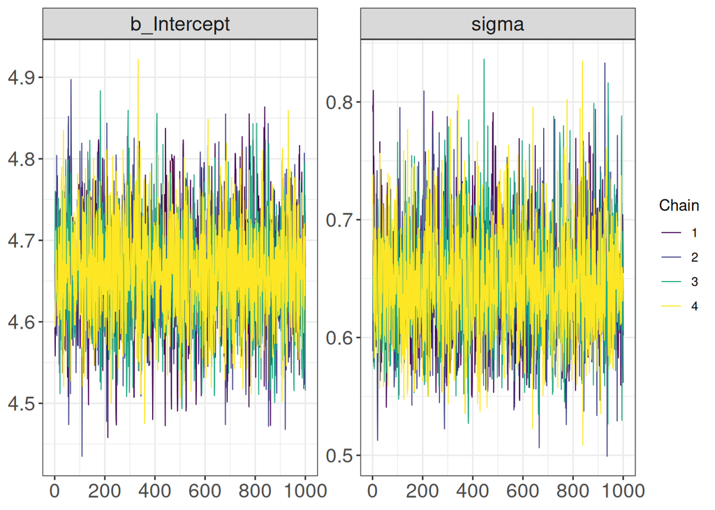

```r
mcmc_trace(normal_draws_brm, pars = c("b_Intercept", "sigma"))
```

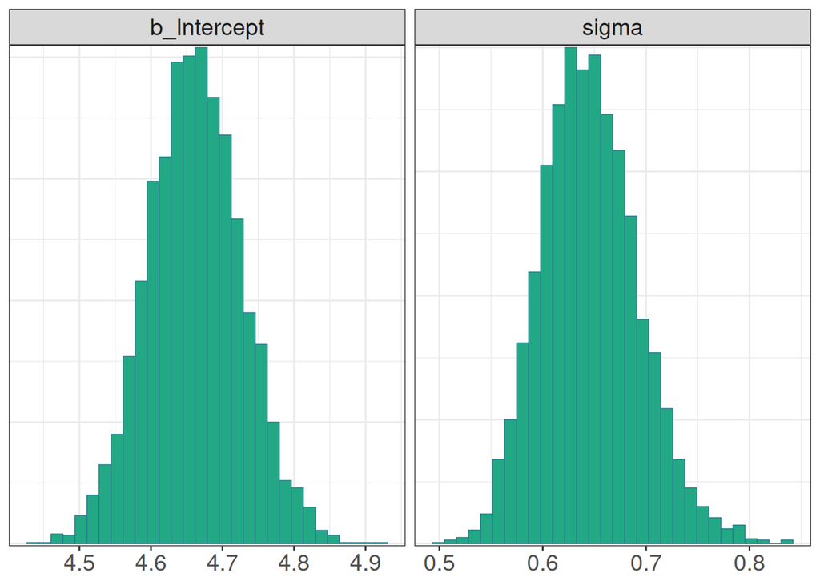

```r
mcmc_hist(normal_draws_brm, pars = c("b_Intercept", "sigma"))
```

### 4.3.3 Diagnostic summary

```r
rstan::check_hmc_diagnostics(normal_fit_brm$fit)
```

```
Divergences:
```

```
0 of 4000 iterations ended with a divergence.
```

```
Tree depth:
```

```
0 of 4000 iterations saturated the maximum tree depth of 10.
```

```
Energy:
```

```
E-BFMI indicated no pathological behavior.
```

# 5 Poisson model

Count data (e.g., species richness, seed counts, pollinator visits…) often follow a Poisson distribution.

$$y_i \sim \text{Poisson}(\lambda)$$

$$y_i \sim \operatorname{Poisson\_log}(\log \lambda)$$

**Q:** What are the mean and variance ($\lambda$) of species richness per plot?

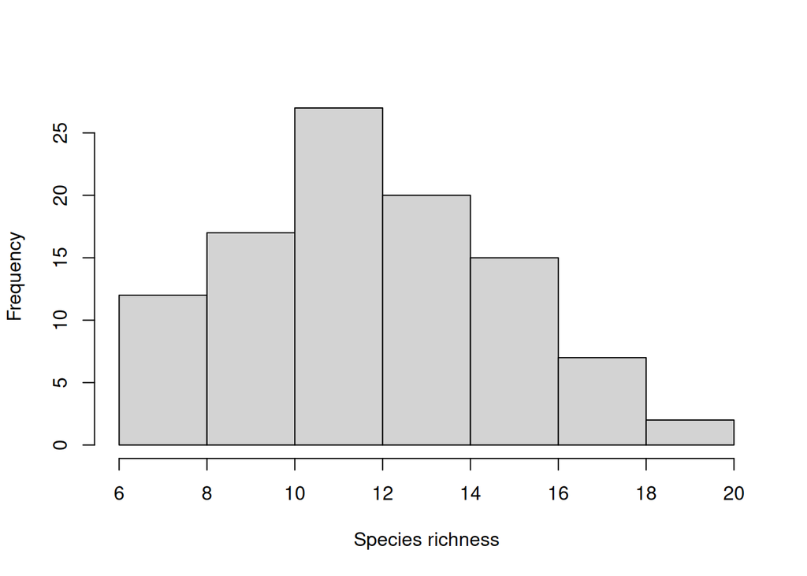

## 5.1 Dummy data

```r
set.seed(123)
y <- rpois(n, lambda = 12.3)

pois_list <- list(
  y = y,
  N = n
)

pois_df <- tibble(
  y = y,
  N = n
)
```

## 5.2 CmdStan

`stan/pois.stan`

```stan
 data {
  int<lower=0> N;
  array[N] int<lower=0> y;
}

parameters {
  real<lower=0> lambda;
}

model {
  y ~ poisson(lambda);
  lambda ~ normal(0, 10);
}
```

`stan/pois_re.stan`

```stan
 data {
  int<lower=0> N;
  array[N] int<lower=0> y;
}

parameters {
  real log_lambda;
}

model {
  y ~ poisson_log(log_lambda);
  log_lambda ~ normal(0, 2.5);
}
```

```r
pois_mod <- cmdstan_model("stan/pois.stan")
pois_re_mod <- cmdstan_model("stan/pois_re.stan")
```

```r
pois_fit <- pois_mod$sample(
  data = pois_list,
  seed = 123,
  chains = 4,
  parallel_chains = 4,
  iter_warmup = 1000, # number of warmup iterations
  iter_sampling = 1000, # number of sampling iterations
  refresh = 0 # print update every 500 iters
)
```

```
Running MCMC with 4 parallel chains...

Chain 1 finished in 0.0 seconds.
Chain 2 finished in 0.0 seconds.
Chain 3 finished in 0.0 seconds.
Chain 4 finished in 0.0 seconds.

All 4 chains finished successfully.
Mean chain execution time: 0.0 seconds.
Total execution time: 0.2 seconds.
```

```r
pois_re_fit <- pois_re_mod$sample(
  data = pois_list,
  seed = 123,
  chains = 4,
  parallel_chains = 4,
  iter_warmup = 1000, # number of warmup iterations
  iter_sampling = 1000, # number of sampling iterations
  refresh = 0 # print update every 500 iters
)
```

```
Running MCMC with 4 parallel chains...

Chain 1 finished in 0.0 seconds.
Chain 2 finished in 0.0 seconds.
Chain 3 finished in 0.0 seconds.
Chain 4 finished in 0.0 seconds.

All 4 chains finished successfully.
Mean chain execution time: 0.0 seconds.
Total execution time: 0.2 seconds.
```

```r
pois_fit$summary()
```

```
# A tibble: 2 × 10
  variable   mean median    sd   mad     q5    q95  rhat ess_bulk ess_tail
  <chr>     <dbl>  <dbl> <dbl> <dbl>  <dbl>  <dbl> <dbl>    <dbl>    <dbl>
1 lp__     1836.  1836.  0.710 0.305 1834.  1836.   1.00    1898.    2556.
2 lambda     12.2   12.2 0.349 0.344   11.6   12.8  1.00    1370.    1871.
```

```r
pois_re_fit$summary()
```

```
# A tibble: 2 × 10
  variable      mean  median     sd    mad     q5    q95  rhat ess_bulk ess_tail
  <chr>        <dbl>   <dbl>  <dbl>  <dbl>  <dbl>  <dbl> <dbl>    <dbl>    <dbl>
1 lp__       1833.   1834.   0.714  0.324  1.83e3 1.83e3  1.00    2170.    2574.
2 log_lambda    2.50    2.50 0.0287 0.0295 2.46e0 2.55e0  1.00    1367.    2197.
```

## 5.3 brms

```r
pois_fit_brm <- brm(y ~ 1,
  family = poisson(),
  data = pois_df,
  refresh = 0,
  backend = "cmdstanr")
```

[output not shown]

[output not shown]

[output not shown]

[output not shown]

[output not shown]

[output not shown]

[output not shown]

[output not shown]

[output not shown]

[output not shown]

[output not shown]

[output not shown]

[output not shown]

```
Running MCMC with 4 sequential chains...

Chain 1 finished in 0.0 seconds.
Chain 2 finished in 0.0 seconds.
Chain 3 finished in 0.0 seconds.
Chain 4 finished in 0.0 seconds.

All 4 chains finished successfully.
Mean chain execution time: 0.0 seconds.
Total execution time: 0.5 seconds.
```

```r
summary(pois_fit_brm)
```

```
 Family: poisson
  Links: mu = log
Formula: y ~ 1
   Data: pois_df (Number of observations: 100)
  Draws: 4 chains, each with iter = 2000; warmup = 1000; thin = 1;
         total post-warmup draws = 4000

Regression Coefficients:
          Estimate Est.Error l-95% CI u-95% CI Rhat Bulk_ESS Tail_ESS
Intercept     2.50      0.03     2.44     2.56 1.00     1650     1850

Draws were sampled using sample(hmc). For each parameter, Bulk_ESS
and Tail_ESS are effective sample size measures, and Rhat is the potential
scale reduction factor on split chains (at convergence, Rhat = 1).
```

# 6 Linear model

The simplest multiple linear regression model is the following, with two predictors ($x_1$ and $x_2$), two slopes ($\beta_1$ and $\beta_2$) and intercept coefficient ($\beta_0$), and normally distributed noise ($\sigma$). This model can be written using standard regression notation as

$$y_i \sim N(\mu_i = \beta_0 + \beta_1 x_{1i} + \beta_2 x_{2i}, \sigma)$$

or

$$y_i \sim N(\mu_i = \boldsymbol{\beta \cdot x_i}, \sigma)$$

where $\boldsymbol{\beta}$ is a 1 $\times$ 3 coefficient matrix (or row vector) and $\boldsymbol{x_i}$ is a 3 $\times$ 1 predictor matrix (including the intercept). We use $\boldsymbol{x}$ (3 $\times$ N) to compute the $\mu$ vector with length $N$.

**Q:** What are the posterior means and 95% credible intervals of the coefficients ($\beta_0$, $\beta_1$, $\beta_2$)?

```r
set.seed(123)
n <- 100
beta <- c(2, 1.2, -0.8)
x1 <- rnorm(n, mean = 0, sd = 1)
x2 <- rnorm(n, mean = 0, sd = 1)
sigma <- 0.4
y <- rnorm(n, mean = beta[1] + beta[2] * x1 + beta[3] * x2, sd = sigma)
```

```r
lm_list <- list(
  y = y,
  N = length(y),
  x = rbind(1, x1, x2) # 3 x N matrix
)

lm_df <- tibble(
  y = y,
  N = length(y),
  x1 = x1,
  x2 = x2
)
```

## 6.1 CmdStan

`stan/lm.stan`

```stan
 data {
  int<lower=0> N;
  vector[N] y;
  matrix[3, N] x;
}

parameters {
  row_vector[3] beta;
  real<lower=0> sigma;
}

model {
  y ~ normal(beta * x, sigma);
  beta ~ normal(0, 2.5);
  sigma ~ cauchy(0, 2.5);
}
```

```r
lm_mod <- cmdstan_model("stan/lm.stan")

lm_fit <- lm_mod$sample(
  data = lm_list,
  seed = 123,
  chains = 4,
  parallel_chains = 4,
  iter_warmup = 1000, # number of warmup iterations
  iter_sampling = 1000, # number of sampling iterations
  refresh = 0 # don't print update
)
```

```
Running MCMC with 4 parallel chains...

Chain 1 finished in 0.0 seconds.
Chain 2 finished in 0.0 seconds.
Chain 3 finished in 0.0 seconds.
Chain 4 finished in 0.0 seconds.

All 4 chains finished successfully.
Mean chain execution time: 0.0 seconds.
Total execution time: 0.2 seconds.
```

Use `posterior::summarise_draws` to check more detailed summary statistics.

```r
my_summary <- function(draws, probs = c(0.025, 0.05, 0.25, 0.5, 0.75, 0.95, 0.975)) {
  posterior::summarise_draws(
    draws,
    mean = ~mean(.x),
    sd   = ~sd(.x),
    ~posterior::quantile2(.x, probs = probs)
  )
}

my_summary(lm_fit$draws())
```

```
# A tibble: 5 × 10
  variable   mean     sd   q2.5     q5    q25    q50    q75    q95  q97.5
  <chr>     <dbl>  <dbl>  <dbl>  <dbl>  <dbl>  <dbl>  <dbl>  <dbl>  <dbl>
1 lp__     44.6   1.43   41.0   41.9   43.9   44.9   45.6   46.2   46.4
2 beta[1]   2.05  0.0393  1.98   1.99   2.03   2.05   2.08   2.12   2.13
3 beta[2]   1.15  0.0417  1.06   1.08   1.12   1.15   1.17   1.21   1.23
4 beta[3]  -0.791 0.0410 -0.869 -0.857 -0.819 -0.791 -0.763 -0.724 -0.708
5 sigma     0.385 0.0285  0.333  0.341  0.365  0.383  0.403  0.433  0.444
```

## 6.2 brms

```r
lm_fit_brm <- brm(
  y ~ x1 + x2,
  family = gaussian(),
  data = lm_df,
  prior = c(
    prior(normal(0, 2.5), class = "Intercept"),
    prior(normal(0, 2.5), class = "b"),
    prior(cauchy(0, 2.5), class = "sigma")
  ),
  refresh = 0, # don't print update
  backend = "cmdstanr"
)
```

```
Running MCMC with 4 sequential chains...

Chain 1 finished in 0.0 seconds.
Chain 2 finished in 0.0 seconds.
Chain 3 finished in 0.0 seconds.
Chain 4 finished in 0.0 seconds.

All 4 chains finished successfully.
Mean chain execution time: 0.0 seconds.
Total execution time: 0.5 seconds.
```

```r
summary(lm_fit_brm)
```

```
 Family: gaussian
  Links: mu = identity
Formula: y ~ x1 + x2
   Data: lm_df (Number of observations: 100)
  Draws: 4 chains, each with iter = 2000; warmup = 1000; thin = 1;
         total post-warmup draws = 4000

Regression Coefficients:
          Estimate Est.Error l-95% CI u-95% CI Rhat Bulk_ESS Tail_ESS
Intercept     2.05      0.04     1.98     2.13 1.00     4619     3168
x1            1.15      0.04     1.06     1.23 1.00     4356     2728
x2           -0.79      0.04    -0.87    -0.71 1.00     4392     3066

Further Distributional Parameters:
      Estimate Est.Error l-95% CI u-95% CI Rhat Bulk_ESS Tail_ESS
sigma     0.39      0.03     0.33     0.45 1.00     4206     2649

Draws were sampled using sample(hmc). For each parameter, Bulk_ESS
and Tail_ESS are effective sample size measures, and Rhat is the potential
scale reduction factor on split chains (at convergence, Rhat = 1).
```

# 7 Varying intercepts

**H:** There is a power-law relationship ($y =\beta_0x^{\beta_1}$) between tree diameter (DBH) and tree maximum height, and the scaling factor $\beta_0$ varies among species.

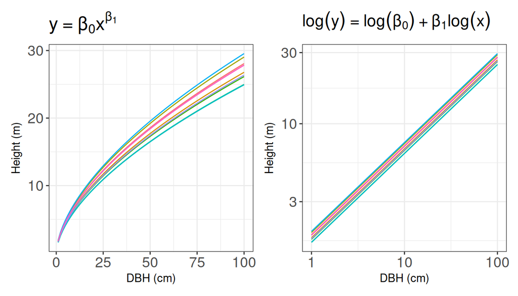

$$\text{log}\; y_{ij} \sim N(\text{log}\; \beta_{0j} + \beta_1 x_{i}, \sigma)$$

$$\text{log}\; \beta_{0j} \sim N(\mu_0, \tau)$$

$$\mu_0 \sim N(0, 2.5)$$

$$\tau \sim \text{Half-Cauchy}(0, 1)$$

**Q:** What are the species-level scaling factors ($\beta_{0j}$) and the global scaling exponent ($\beta_1$)?

## 7.1 Dummy data

- We simulate a dataset with 10 species and 20 trees per species.
- Each species has wood density (wd) values.

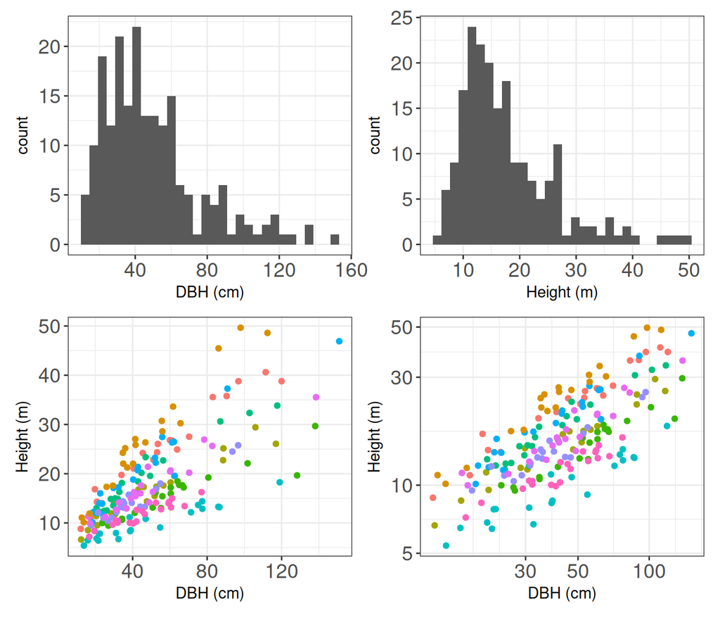

```r
set.seed(12345)

n_sp <- 10
n_rep <- 20
wd <- rnorm(n_sp, 0, 1)
gamma0 <- 0.6
gamma1 <- 0.1
sigma_y <- 0.1

b1_hat <- gamma1 * wd + gamma0
b1 <- rnorm(n_sp, b1_hat, 0.01)
log_b0 <- rnorm(n_sp, 0.55, 0.05)

# ---- simulate ----
allo_df <- tibble(
  sp     = factor(rep(paste0("sp", 1:n_sp), each = n_rep)),
  wd  = rep(wd, each = n_rep),
  # now log_xx ~ Normal(mean log-dbh, sd = 0.5)
  log_xx = rnorm(n_sp * n_rep, mean = log(40), sd = 0.5)) |>
  mutate(
    # add observation-level noise on log-height
    log_y = rnorm(
      n(),
      log_b0[as.integer(sp)] + b1[as.integer(sp)] * log_xx,
      sigma_y),
    dbh = exp(log_xx),
    h = exp(log_y)) |>
  select(sp, wd, dbh, h)

dbh_hist <- allo_df |>
  ggplot(aes(dbh)) +
  geom_histogram() +
  xlab("DBH (cm)") +
  theme(
    legend.position = "none",
    plot.title = element_text(size = 24)
    )

h_hist <- allo_df |>
  ggplot(aes(h)) +
  geom_histogram() +
  xlab("Height (m)") +
  theme(
    legend.position = "none",
    plot.title = element_text(size = 24)
    )

p1 <- allo_df |>
  ggplot(aes(x = dbh, y = h, col = sp)) +
  geom_point() +
  xlab("DBH (cm)") +
  ylab(expression("Height (m)")) +
  theme(
    legend.position = "none",
    plot.title = element_text(size = 24)
    )

p2 <- p1 +
  scale_x_log10() +
  scale_y_log10()


dbh_hist + h_hist + p1 + p2
```

```r
allo_list <- list(
  log_h = log(allo_df$h),
  log_dbh = log(allo_df$dbh),
  sp = as.integer(allo_df$sp),
  N = nrow(allo_df),
  J = allo_df$sp |> unique() |> length()
)
```

## 7.2 CmdStan

`stan/vint.stan`

```stan
 data {
  int<lower=1> N;               // total number of observations
  int<lower=1> J;               // number of species
  array[N] int<lower=1, upper=J> sp; // sp index
  vector[N] log_dbh;            // predictor: log(DBH)
  vector[N] log_h;              // response: log(height)
}

parameters {
  real        mu0;         // grand mean of log(mu₀)
  real<lower=0> tau;            // SD of species intercepts
  vector[J]   log_beta0;            // species‐level intercepts = log(β₀ⱼ)
  real        beta1;            // common slope on log(DBH)
  real<lower=0> sigma;          // residual SD
}

model {
  // Likelihood
  log_h ~ normal(log_beta0[sp] + beta1 * log_dbh, sigma);

  // Priors
  mu0 ~ normal(0, 2.5);
  tau      ~ cauchy(0, 1);
  log_beta0  ~ normal(mu0, tau);
  beta1    ~ normal(0, 2.5);
  sigma    ~ cauchy(0, 1);
}

// we need this for model selection
generated quantities {
  vector[N] log_lik;
  for (i in 1:N)
    log_lik[i] = normal_lpdf(log_h[i]
                    | log_beta0[sp[i]] + beta1 * log_dbh[i],
                      sigma);
}
```

```r
vint_mod <- cmdstan_model("stan/vint.stan")

vint_fit <- vint_mod$sample(
  data = allo_list,
  seed = 123,
  chains = 4,
  parallel_chains = 4,
  iter_warmup = 1000, # number of warmup iterations
  iter_sampling = 1000, # number of sampling iterations
  refresh = 0 # don't print update
)
```

```
Running MCMC with 4 parallel chains...
```

[output not shown]

[output not shown]

[output not shown]

[output not shown]

```
Chain 1
```

[output not shown]

[output not shown]

[output not shown]

[output not shown]

```
Chain 2
```

[output not shown]

[output not shown]

[output not shown]

[output not shown]

```
Chain 3
```

```
Chain 1 finished in 0.3 seconds.
Chain 2 finished in 0.3 seconds.
Chain 3 finished in 0.3 seconds.
Chain 4 finished in 0.3 seconds.

All 4 chains finished successfully.
Mean chain execution time: 0.3 seconds.
Total execution time: 0.4 seconds.
```

```r
#vint_fit$summary()
my_summary(vint_fit$draws())
```

```
# A tibble: 215 × 10
   variable        mean     sd    q2.5      q5      q25      q50     q75     q95
   <chr>          <dbl>  <dbl>   <dbl>   <dbl>    <dbl>    <dbl>   <dbl>   <dbl>
 1 lp__        365.     2.71   359.    360.    364.     366.     3.67e+2 3.69e+2
 2 mu0           0.479  0.121    0.239   0.280   0.403    0.479  5.54e-1 6.68e-1
 3 tau           0.333  0.0909   0.208   0.220   0.269    0.315  3.79e-1 5.05e-1
 4 log_beta0[…   0.779  0.0565   0.671   0.686   0.740    0.778  8.16e-1 8.74e-1
 5 log_beta0[…   0.918  0.0542   0.812   0.830   0.880    0.916  9.55e-1 1.01e+0
 6 log_beta0[…   0.436  0.0554   0.331   0.345   0.398    0.436  4.74e-1 5.28e-1
 7 log_beta0[…   0.261  0.0582   0.150   0.166   0.222    0.261  3.01e-1 3.58e-1
 8 log_beta0[…   0.617  0.0534   0.514   0.529   0.580    0.617  6.53e-1 7.06e-1
 9 log_beta0[…  -0.0183 0.0546  -0.124  -0.107  -0.0563  -0.0185 1.93e-2 7.34e-2
10 log_beta0[…   0.707  0.0534   0.605   0.622   0.669    0.706  7.43e-1 7.96e-1
# ℹ 205 more rows
# ℹ 1 more variable: q97.5 <dbl>
```

```r
vint_fit$diagnostic_summary()
```

```
$num_divergent
[1] 0 0 0 0

$num_max_treedepth
[1] 0 0 0 0

$ebfmi
[1] 1.0810518 0.9796202 1.0400008 0.9993418
```

## 7.3 brms

```r
priors <- c(
  prior(normal(0, 2.5), class = Intercept),
  prior(normal(0, 2.5),   class = b),
  prior(cauchy(0, 1),   class = sd),
  prior(cauchy(0, 1),   class = sigma)
)

vint_fit_brm <- brm(
  log(h) ~ log(dbh) + (1 | sp),
  family = gaussian(),
  data = allo_df,
  prior = priors,
  seed = 123,
  refresh = 0, # don't print update
  backend = "cmdstanr"
)
```

```
Running MCMC with 4 sequential chains...

Chain 1 finished in 0.7 seconds.
Chain 2 finished in 0.7 seconds.
Chain 3 finished in 0.7 seconds.
Chain 4 finished in 0.6 seconds.

All 4 chains finished successfully.
Mean chain execution time: 0.7 seconds.
Total execution time: 2.9 seconds.
```

```r
summary(vint_fit_brm)
```

```
 Family: gaussian
  Links: mu = identity
Formula: log(h) ~ log(dbh) + (1 | sp)
   Data: allo_df (Number of observations: 200)
  Draws: 4 chains, each with iter = 2000; warmup = 1000; thin = 1;
         total post-warmup draws = 4000

Multilevel Hyperparameters:
~sp (Number of levels: 10)
              Estimate Est.Error l-95% CI u-95% CI Rhat Bulk_ESS Tail_ESS
sd(Intercept)     0.34      0.10     0.21     0.58 1.00      590     1242

Regression Coefficients:
          Estimate Est.Error l-95% CI u-95% CI Rhat Bulk_ESS Tail_ESS
Intercept     0.48      0.12     0.25     0.71 1.00      897     1238
logdbh        0.61      0.01     0.58     0.64 1.00     2371     2261

Further Distributional Parameters:
      Estimate Est.Error l-95% CI u-95% CI Rhat Bulk_ESS Tail_ESS
sigma     0.10      0.01     0.09     0.11 1.00     2165     2143

Draws were sampled using sample(hmc). For each parameter, Bulk_ESS
and Tail_ESS are effective sample size measures, and Rhat is the potential
scale reduction factor on split chains (at convergence, Rhat = 1).
```

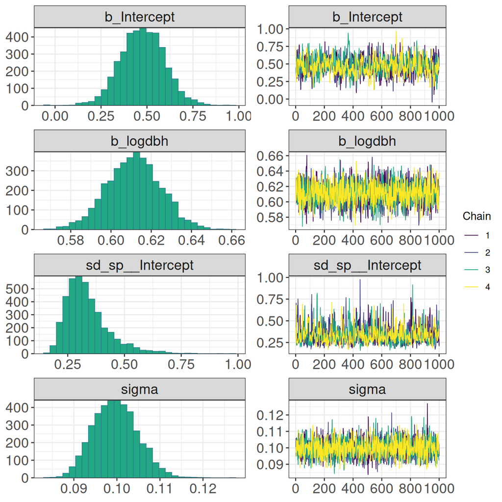

```r
plot(vint_fit_brm)
```

## 7.4 lme4

```r
vint_fit_lme <- lme4::lmer(
  log(h) ~ log(dbh) + (1 | sp),
  data = allo_df)

summary(vint_fit_lme)
```

```
Linear mixed model fit by REML ['lmerMod']
Formula: log(h) ~ log(dbh) + (1 | sp)
   Data: allo_df

REML criterion at convergence: -298.3

Scaled residuals:
     Min       1Q   Median       3Q      Max
-2.66966 -0.62316  0.04254  0.60122  2.28315

Random effects:
 Groups   Name        Variance Std.Dev.
 sp       (Intercept) 0.084434 0.29057
 Residual             0.009794 0.09897
Number of obs: 200, groups:  sp, 10

Fixed effects:
            Estimate Std. Error t value
(Intercept)  0.47916    0.10454   4.584
log(dbh)     0.61154    0.01314  46.525

Correlation of Fixed Effects:
         (Intr)
log(dbh) -0.472
```

## 7.5 Visualization and predictions

### 7.5.1 CmdStan

```r
# Predicted DBH-height curves per species with 95% intervals
pred_grid <- allo_df |>
  dplyr::group_by(sp) |>
  dplyr::summarise(
    dbh = list(seq(min(dbh), max(dbh), length.out = 60)),
    .groups = "drop"
  ) |>
  tidyr::unnest(dbh)

cmd_draws <- posterior::as_draws_matrix(vint_fit$draws(c("beta1", "log_beta0")))
beta1_draws <- cmd_draws[, "beta1"]
log_beta0_cols <- grep("^log_beta0\\[", colnames(cmd_draws), value = TRUE)
species_levels <- levels(allo_df$sp)
```

DBH for predicted lines for each species.

```r
pred_grid
```

```
# A tibble: 600 × 2
   sp      dbh
   <fct> <dbl>
 1 sp1    12.2
 2 sp1    14.0
 3 sp1    15.8
 4 sp1    17.6
 5 sp1    19.5
 6 sp1    21.3
 7 sp1    23.1
 8 sp1    25.0
 9 sp1    26.8
10 sp1    28.6
# ℹ 590 more rows
```

Posterior draws of the slope parameter ($\beta_1$).

```r
str(beta1_draws)
```

```
 'draws_matrix' num [1:4000, 1] 0.615 0.614 0.598 0.609 0.61 ...
 - attr(*, "dimnames")=List of 2
  ..$ draw    : chr [1:4000] "1" "2" "3" "4" ...
  ..$ variable: chr "beta1"
 - attr(*, "nchains")= int 4
```

Column names for log-transformed species-level intercepts ($\log \beta_{0j}$). We use this to extract posterior draws for each species.

```r
str(log_beta0_cols)
```

```
 chr [1:10] "log_beta0[1]" "log_beta0[2]" "log_beta0[3]" "log_beta0[4]" ...
```

```r
pred_cmd_summary <- dplyr::bind_cols(
  pred_grid,
  purrr::map2_dfr(
    match(pred_grid$sp, species_levels),
    log(pred_grid$dbh),
    ~{
      log_mu <- cmd_draws[, log_beta0_cols[.x]] + beta1_draws * .y
      height_draws <- exp(log_mu)
      tibble::tibble(
        estimate = stats::median(height_draws),
        lower = stats::quantile(height_draws, 0.025),
        upper = stats::quantile(height_draws, 0.975)
      )
    }
  )
)
```

Compute predicted height summary for each species and DBH.

```r
pred_cmd_summary
```

```
# A tibble: 600 × 5
   sp      dbh estimate lower upper
   <fct> <dbl>    <dbl> <dbl> <dbl>
 1 sp1    12.2     10.0  9.50  10.7
 2 sp1    14.0     10.9 10.4   11.6
 3 sp1    15.8     11.8 11.2   12.5
 4 sp1    17.6     12.6 12.0   13.3
 5 sp1    19.5     13.4 12.8   14.1
 6 sp1    21.3     14.2 13.5   14.9
 7 sp1    23.1     14.9 14.2   15.6
 8 sp1    25.0     15.6 14.9   16.4
 9 sp1    26.8     16.3 15.6   17.1
10 sp1    28.6     17.0 16.2   17.8
# ℹ 590 more rows
```

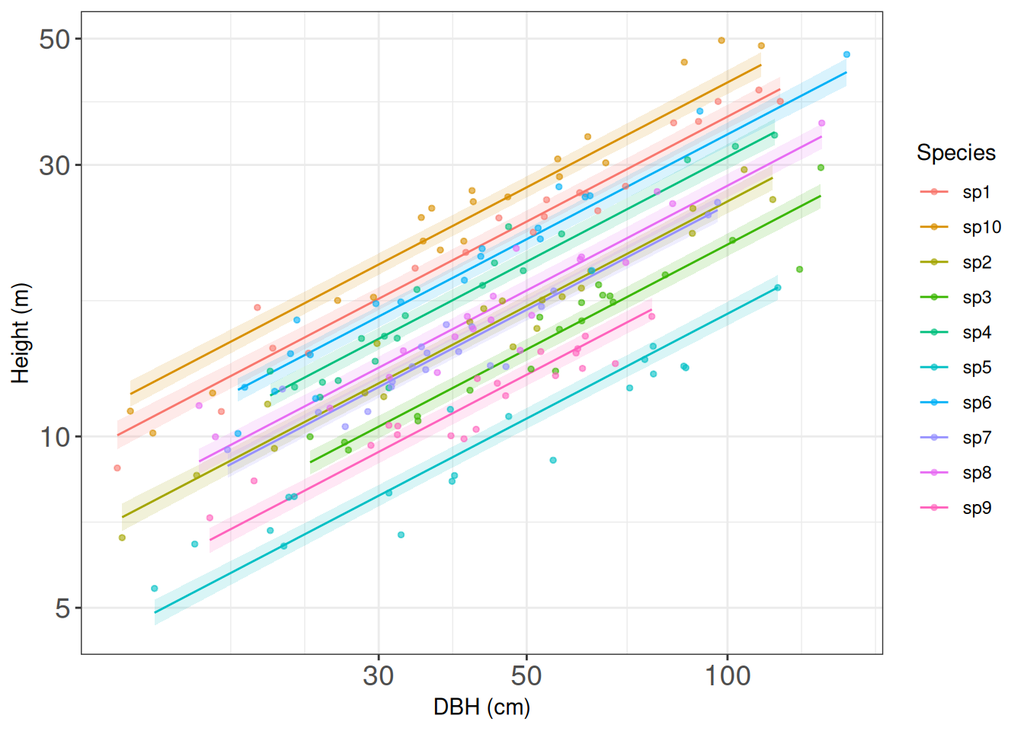

```r
ggplot(pred_cmd_summary, aes(dbh, estimate, colour = sp)) +
  geom_ribbon(aes(ymin = lower, ymax = upper, fill = sp), alpha = 0.15, colour = NA) +
  geom_line() +
  geom_point(
    data = allo_df,
    aes(dbh, h, colour = sp),
    size = 1,
    alpha = 0.6,
    inherit.aes = FALSE
  ) +
  scale_x_log10() +
  scale_y_log10() +
  guides(fill = "none") +
  labs(
    x = "DBH (cm)",
    y = "Height (m)",
    colour = "Species"
  )
```

### 7.5.2 brms

With `fitted()` available, preparing `pred_summary` is simpler than in the CmdStan workflow.

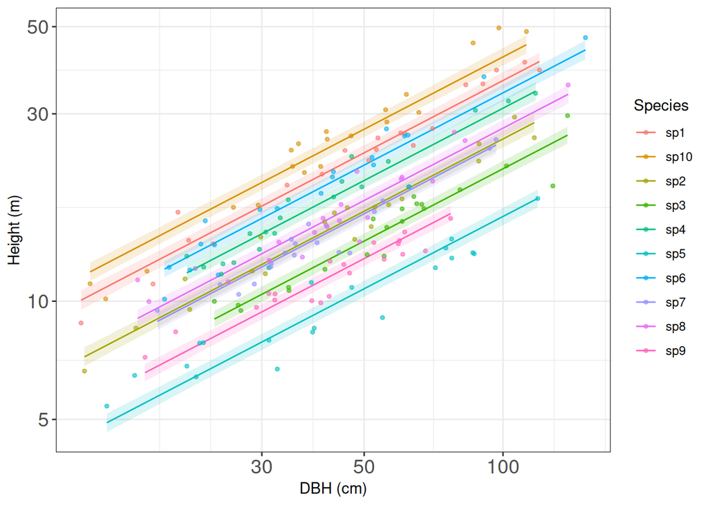

```r
pred_summary <- fitted(vint_fit_brm, newdata = pred_grid, re_formula = NULL) |>
  tibble::as_tibble() |>
  dplyr::bind_cols(pred_grid) |>
  dplyr::mutate(
    estimate = exp(Estimate),
    lower = exp(Q2.5),
    upper = exp(Q97.5)
  )

ggplot(pred_summary, aes(dbh, estimate, color = sp)) +
  geom_ribbon(aes(ymin = lower, ymax = upper, fill = sp), alpha = 0.15, colour = NA) +
  geom_line() +
  geom_point(
    data = allo_df,
    aes(dbh, h, colour = sp),
    size = 1,
    alpha = 0.6,
    inherit.aes = FALSE
  ) +
  scale_x_log10() +
  scale_y_log10() +
  guides(fill = "none") +
  labs(
    x = "DBH (cm)",
    y = "Height (m)",
    colour = "Species"
  )
```

# 8 Reparameterization for multilevel models

[Diagnosing Biased Inference with Divergences](https://betanalpha.github.io/assets/case_studies/divergences_and_bias.html#3_a_non-centered_eight_schools_implementation) by Michael Betancourt

## 8.1 Eight schools example

What is the effect of the treatment (a new education method) on students’ scores for each school and across schools?

| school | y | sigma |
| --- | --- | --- |
| School_1 | 28 | 15 |
| School_2 | 8 | 10 |
| School_3 | -3 | 16 |
| School_4 | 7 | 11 |
| School_5 | -1 | 9 |
| School_6 | 1 | 11 |
| School_7 | 18 | 10 |
| School_8 | 12 | 18 |

## 8.2 Centered parameterization

$$y_j \sim \mathcal{N}\bigl(\theta_j,\;\sigma_j\bigr)$$

$$\theta_j \sim \mathcal{N}\bigl(\mu,\;\tau \bigr)$$

$$\mu \sim \mathcal{N}\bigl(0,\;5 \bigr)$$

$$\tau \sim \text{Half-Cauchy}(0, 2.5)$$

*Note: $\sigma_j$ is known constant (i.e., data), we don’t have to estimate it.*

This parameterization is intuitive, but it often leads to convergence issues in hierarchical models.

## 8.3 Non-centered parameterization

$$\tilde{\theta_j} \sim \mathcal{N}\bigl(0,\;1 \bigr)$$

$$\theta_j = \mu + \tau \cdot \tilde{\theta_j}$$

In this parameterization, we introduce a new latent variable $\tilde{\theta_j}$ that is independent of the other parameters. This allows the sampler to explore the posterior more efficiently and avoids problems with convergence. We often use this parameterization when we have hierarchical models with varying intercepts or slopes.

# 9 Varying slopes and intercepts

**H:** There is a power-law relationship ($y =\beta_0 x^{\beta_1}$) between tree diameter (DBH) and tree maximum height, and both the scaling factor $\beta_0$ and the exponent $\beta_1$ vary among species.

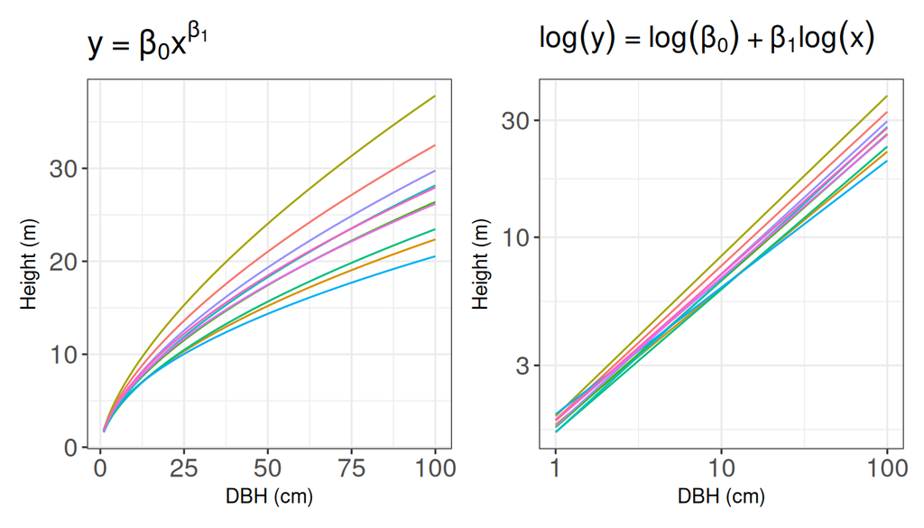

$$\text{log}\; y_{ij} \sim N(\text{log}\; \beta_{0j} + \beta_{1j} x_{ij}, \sigma)$$

$$\begin{bmatrix}
\text{log}\; \beta_{0j} \\
\beta_{1j}
\end{bmatrix}
\sim
\mathrm{MVN}
\Biggl(
\boldsymbol{\mu} =
\begin{bmatrix}
\mu_{0} \\
\mu_{1}
\end{bmatrix},
\boldsymbol{\Sigma} =
\begin{bmatrix}
\sigma_{0}^2 & \rho \sigma_{0} \sigma_{1} \\
\rho \sigma_{0} \sigma_{1} & \sigma_{1}^2
\end{bmatrix}
\Biggr)$$

For reference, the multivariate normal (MVN) distribution looks like this:

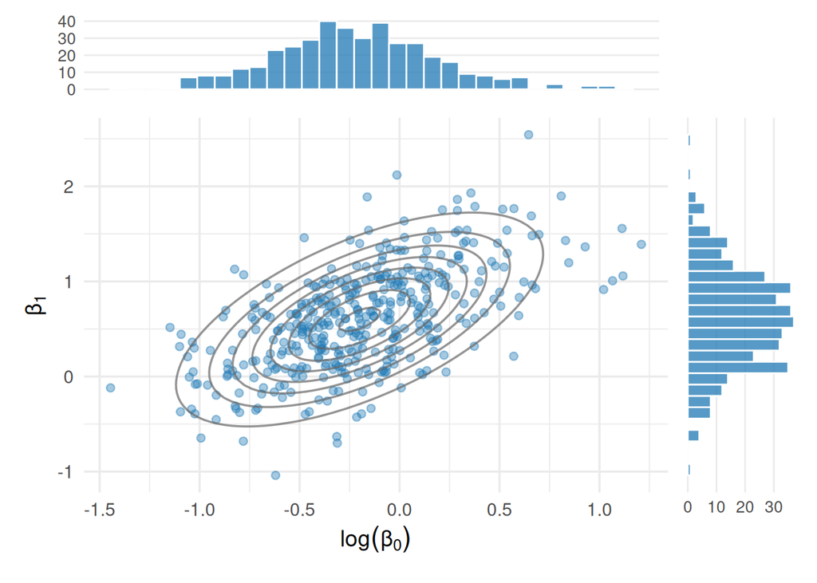

**Q:** What are the species-level scaling factors ($\beta_{0j}$) and scaling exponent ($\beta_{0j}$)? What are the global scaling exponent ($\mu_0$) and scaling exponent ($\mu_1$)?

## 9.1 Centered parameterization

$$\boldsymbol{\mu} \sim N(0, 2.5)$$

$$\boldsymbol{\Sigma} \sim \mathcal{W}^{-1}_p(\nu,\,\Psi)$$

The inverse-whishart distribution $\mathcal{W}^{-1}$ is a conjugate for the covariance matrix $\boldsymbol{\Sigma}$ in MVN. However, despite conjugacy, inverse–Wishart priors are often computationally difficult to sample.

Recommendation: use a Cholesky factorization with independent priors on scales and correlation (below).

## 9.2 Non-Centered parameterization

[Optimization through Cholesky factorization](https://mc-stan.org/docs/stan-users-guide/regression.html#hierarchical-priors.section)

$$\boldsymbol{z}_j \sim \mathcal{N}(\mathbf0,\,I_2)$$
$$\begin{pmatrix}\log\beta_{0j}\\[3pt]\beta_{1j}\end{pmatrix}
= \boldsymbol{\mu} + L\, \boldsymbol{z}_j$$

Some linear algebra (Cholesky decomposition):

$$\Sigma \;=\;L\,L^\top
\;=\;\bigl[\mathrm{diag}(\tau)\,L_\Omega\bigr]\,
\bigl[L_\Omega^\top\,\mathrm{diag}(\tau)\bigr]
\;=\;\mathrm{diag}(\tau)\,\Omega\,\mathrm{diag}(\tau).$$

Rather than sampling the covariance matrix $\Sigma$ or correlation matrix $\Omega$ directly, sampling the Cholesky factor $L_\Omega$ is computationally more efficient and numerically stable.

In the LKJ() prior:

- $\eta = 1$ indicates a flat prior (uniform distribution) over correlation matrices.
- $\eta > 1$ indicates weaker correlations.

We usually use $\eta = 2$ because we assume at least weak correlations among the parameters while still allowing moderate to strong correlations.

## 9.3 CmdStan

`stan/vslope.stan`

```stan
 data {
  int<lower=0> N;              // num individuals
  int<lower=1> K;              // num ind predictors
  int<lower=1> J;              // num groups
  array[N] int<lower=1, upper=J> jj;  // group for individual
  int<lower=1> L;              // number of group-level predictors
  matrix[N, K] x;              // individual predictors
  matrix[L, J] u;              // group predictors
  vector[N] y;                 // outcomes
}

parameters {
  matrix[K, L] gamma;          // coefficients across groups
  real<lower=0> sigma;         // prediction error scale
  vector<lower=0>[K] tau;      // prior scale
  matrix[K, J] z;
  cholesky_factor_corr[K] L_Omega;
}

transformed parameters {
  matrix[K, J] beta;
  // mu = gamma * u
  beta = gamma * u + diag_pre_multiply(tau, L_Omega) * z;
}

model {
  to_vector(z) ~ std_normal();
  tau ~ cauchy(0, 2.5);
  L_Omega ~ lkj_corr_cholesky(2);
  to_vector(gamma) ~ normal(0, 2.5);
  for (n in 1:N) {
    y[n] ~ normal(x[n, ] * beta[, jj[n]], sigma);
  }
}
```

```r
allo_vslope_list <- list(
  y = log(allo_df$h),
  x = cbind(1, log(allo_df$dbh)),
  jj = as.integer(allo_df$sp),
  N = nrow(allo_df),
  K = 2, # number of predictors (intercept + slope)
  J = allo_df$sp |> unique() |> length(),
  L = 1 # number of group-level predictors (intercept)
)
allo_vslope_list$u <- matrix(1, nrow = allo_vslope_list$L, ncol = allo_vslope_list$J)
```

```r
vslope_mod <- cmdstan_model("stan/vslope.stan")

vslope_fit <- vslope_mod$sample(
  data = allo_vslope_list,
  seed = 123,
  chains = 4,
  parallel_chains = 4,
  iter_warmup = 1000, # number of warmup iterations
  iter_sampling = 1000, # number of sampling iterations
  adapt_delta = 0.99, # increase adapt_delta to avoid divergent transitions
  max_treedepth = 15, # increase max_treedepth to avoid max treedepth errors
  refresh = 0, # don't print update
  show_messages = FALSE   # suppress Stan’s “Informational Message” output
)
```

[output not shown]

[output not shown]

[output not shown]

[output not shown]

[output not shown]

[output not shown]

[output not shown]

[output not shown]

[output not shown]

[output not shown]

[output not shown]

[output not shown]

[output not shown]

[output not shown]

[output not shown]

[output not shown]

[output not shown]

[output not shown]

[output not shown]

[output not shown]

[output not shown]

[output not shown]

[output not shown]

[output not shown]

[output not shown]

[output not shown]

[output not shown]

[output not shown]

[output not shown]

[output not shown]

[output not shown]

[output not shown]

[output not shown]

[output not shown]

[output not shown]

[output not shown]

[output not shown]

[output not shown]

[output not shown]

[output not shown]

[output not shown]

[output not shown]

[output not shown]

[output not shown]

[output not shown]

[output not shown]

[output not shown]

[output not shown]

[output not shown]

[output not shown]

[output not shown]

[output not shown]

[output not shown]

[output not shown]

[output not shown]

[output not shown]

[output not shown]

[output not shown]

[output not shown]

[output not shown]

[output not shown]

[output not shown]

[output not shown]

[output not shown]

[output not shown]

[output not shown]

[output not shown]

[output not shown]

[output not shown]

[output not shown]

[output not shown]

[output not shown]

[output not shown]

[output not shown]

[output not shown]

[output not shown]

[output not shown]

[output not shown]

[output not shown]

[output not shown]

[output not shown]

[output not shown]

[output not shown]

[output not shown]

[output not shown]

[output not shown]

[output not shown]

[output not shown]

[output not shown]

[output not shown]

[output not shown]

[output not shown]

[output not shown]

[output not shown]

[output not shown]

[output not shown]

[output not shown]

[output not shown]

[output not shown]

[output not shown]

```r
my_summary(vslope_fit$draws())
```

```
# A tibble: 50 × 10
   variable      mean      sd     q2.5       q5      q25     q50     q75     q95
   <chr>        <dbl>   <dbl>    <dbl>    <dbl>    <dbl>   <dbl>   <dbl>   <dbl>
 1 lp__       3.60e+2 4.39     3.50e+2  3.52e+2 357.     3.60e+2 3.63e+2 366.
 2 gamma[1,1] 5.01e-1 0.0555   3.91e-1  4.10e-1   0.465  5.02e-1 5.38e-1   0.591
 3 gamma[2,1] 6.07e-1 0.0313   5.47e-1  5.56e-1   0.587  6.06e-1 6.26e-1   0.660
 4 sigma      9.24e-2 0.00481  8.37e-2  8.49e-2   0.0889 9.21e-2 9.55e-2   0.101
 5 tau[1]     7.10e-2 0.0570   2.34e-3  4.79e-3   0.0278 5.94e-2 9.96e-2   0.181
 6 tau[2]     8.75e-2 0.0290   4.73e-2  5.14e-2   0.0679 8.24e-2 1.01e-1   0.142
 7 z[1,1]     6.05e-1 0.895   -1.27e+0 -9.15e-1   0.0410 6.46e-1 1.23e+0   2.01
 8 z[2,1]     6.61e-1 0.653   -7.88e-1 -5.21e-1   0.286  7.03e-1 1.09e+0   1.65
 9 z[1,2]     1.95e-1 0.975   -1.83e+0 -1.50e+0  -0.441  2.23e-1 8.80e-1   1.73
10 z[2,2]     1.30e+0 0.658   -4.72e-2  1.93e-1   0.900  1.32e+0 1.73e+0   2.33
# ℹ 40 more rows
# ℹ 1 more variable: q97.5 <dbl>
```

```r
vslope_fit$diagnostic_summary()
```

```
$num_divergent
[1] 0 0 0 0

$num_max_treedepth
[1] 0 0 0 0

$ebfmi
[1] 0.8136123 0.8535260 0.8342642 0.7602623
```

## 9.4 brms

```r
priors <- c(
  prior(normal(0, 2.5), class = Intercept),
  prior(normal(0, 2.5),   class = b),
  prior(lkj(2), class = cor),                # Ω ~ LKJ(2)
  prior(cauchy(0, 2.5), class = sigma)
)

slope_fit_brm <- brm(
  log(h) ~ log(dbh) + (1 + log(dbh) | sp),
  family = gaussian(),
  data = allo_df,
  prior = priors,
  refresh = 0, # don't print update
  seed = 123,
  chains = 4, cores = 4,
  control = list(
    adapt_delta  = 0.99,  # default is 0.8
    max_treedepth = 15    # default is 10
  ),
  backend = "cmdstanr"
)
```

```
Running MCMC with 4 parallel chains...

Chain 1 finished in 7.2 seconds.
Chain 4 finished in 9.3 seconds.
Chain 3 finished in 10.0 seconds.
Chain 2 finished in 10.3 seconds.

All 4 chains finished successfully.
Mean chain execution time: 9.2 seconds.
Total execution time: 10.4 seconds.
```

```r
summary(slope_fit_brm)
```

```
 Family: gaussian
  Links: mu = identity
Formula: log(h) ~ log(dbh) + (1 + log(dbh) | sp)
   Data: allo_df (Number of observations: 200)
  Draws: 4 chains, each with iter = 2000; warmup = 1000; thin = 1;
         total post-warmup draws = 4000

Multilevel Hyperparameters:
~sp (Number of levels: 10)
                      Estimate Est.Error l-95% CI u-95% CI Rhat Bulk_ESS
sd(Intercept)             0.07      0.06     0.00     0.21 1.00     1853
sd(logdbh)                0.09      0.03     0.05     0.16 1.00     1320
cor(Intercept,logdbh)     0.09      0.42    -0.74     0.84 1.00      672
                      Tail_ESS
sd(Intercept)             1523
sd(logdbh)                1835
cor(Intercept,logdbh)     1251

Regression Coefficients:
          Estimate Est.Error l-95% CI u-95% CI Rhat Bulk_ESS Tail_ESS
Intercept     0.50      0.05     0.40     0.61 1.00     3410     3243
logdbh        0.60      0.03     0.54     0.66 1.00     1362     1765

Further Distributional Parameters:
      Estimate Est.Error l-95% CI u-95% CI Rhat Bulk_ESS Tail_ESS
sigma     0.09      0.00     0.08     0.10 1.00     6219     2878

Draws were sampled using sample(hmc). For each parameter, Bulk_ESS
and Tail_ESS are effective sample size measures, and Rhat is the potential
scale reduction factor on split chains (at convergence, Rhat = 1).
```

## 9.5 lme4

```r
slope_fit_lme <- lme4::lmer(
  log(h) ~ log(dbh) + (1 + log(dbh) | sp),
  data = allo_df)
```

```
boundary (singular) fit: see help('isSingular')
```

```r
summary(slope_fit_lme)
```

```
Linear mixed model fit by REML ['lmerMod']
Formula: log(h) ~ log(dbh) + (1 + log(dbh) | sp)
   Data: allo_df

REML criterion at convergence: -327.2

Scaled residuals:
     Min       1Q   Median       3Q      Max
-3.14307 -0.63987  0.08714  0.61696  3.03735

Random effects:
 Groups   Name        Variance Std.Dev. Corr
 sp       (Intercept) 0.001326 0.03641
          log(dbh)    0.004607 0.06787  1.00
 Residual             0.008397 0.09164
Number of obs: 200, groups:  sp, 10

Fixed effects:
            Estimate Std. Error t value
(Intercept)  0.49980    0.04759   10.50
log(dbh)     0.60637    0.02468   24.57

Correlation of Fixed Effects:
         (Intr)
log(dbh) -0.264
optimizer (nloptwrap) convergence code: 0 (OK)
boundary (singular) fit: see help('isSingular')
```

## 9.6 Visualization

Almost the same as before, but now we have varying slopes as well as intercepts.

### 9.6.1 CmdStan

```r
vslope_matrix <- posterior::as_draws_matrix(vslope_fit$draws("beta"))
intercept_cols <- grep("^beta\\[1,", colnames(vslope_matrix), value = TRUE)
slope_cols <- grep("^beta\\[2,", colnames(vslope_matrix), value = TRUE)

str(vslope_matrix)
```

```
 'draws_matrix' num [1:4000, 1:20] 0.749 0.482 0.469 0.633 0.688 ...
 - attr(*, "dimnames")=List of 2
  ..$ draw    : chr [1:4000] "1" "2" "3" "4" ...
  ..$ variable: chr [1:20] "beta[1,1]" "beta[2,1]" "beta[1,2]" "beta[2,2]" ...
 - attr(*, "nchains")= int 4
```

```r
str(intercept_cols)
```

```
 chr [1:10] "beta[1,1]" "beta[1,2]" "beta[1,3]" "beta[1,4]" "beta[1,5]" ...
```

```r
str(slope_cols)
```

```
 chr [1:10] "beta[2,1]" "beta[2,2]" "beta[2,3]" "beta[2,4]" "beta[2,5]" ...
```

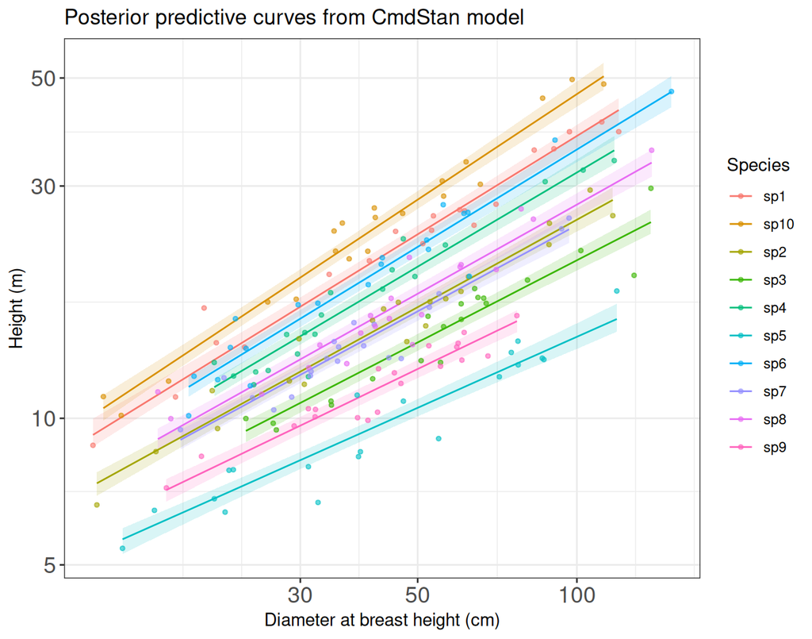

```r
pred_grid_vslope <- pred_grid |>
  dplyr::mutate(log_dbh = log(dbh))

pred_cmd_summary <- dplyr::bind_cols(
  pred_grid_vslope,
  purrr::map2_dfr(
    match(pred_grid_vslope$sp, species_levels),
    pred_grid_vslope$log_dbh,
    ~{
      intercept_draws <- vslope_matrix[, intercept_cols[.x]]
      slope_draws <- vslope_matrix[, slope_cols[.x]]
      log_mu <- intercept_draws + slope_draws * .y
      height_draws <- exp(log_mu)
      tibble::tibble(
        estimate = stats::median(height_draws),
        lower = stats::quantile(height_draws, 0.025),
        upper = stats::quantile(height_draws, 0.975)
      )
    }
  )
)

ggplot(pred_cmd_summary, aes(dbh, estimate, colour = sp)) +
  geom_ribbon(
    aes(ymin = lower, ymax = upper, fill = sp),
    alpha = 0.15,
    colour = NA
  ) +
  geom_line() +
  geom_point(
    data = allo_df,
    aes(dbh, h, colour = sp),
    size = 1,
    alpha = 0.6,
    inherit.aes = FALSE
  ) +
  scale_x_log10() +
  scale_y_log10() +
  guides(fill = "none", colour = guide_legend(title = "Species")) +
  labs(
    x = "Diameter at breast height (cm)",
    y = "Height (m)",
    title = "Posterior predictive curves from CmdStan model"
  )
```

### 9.6.2 brms

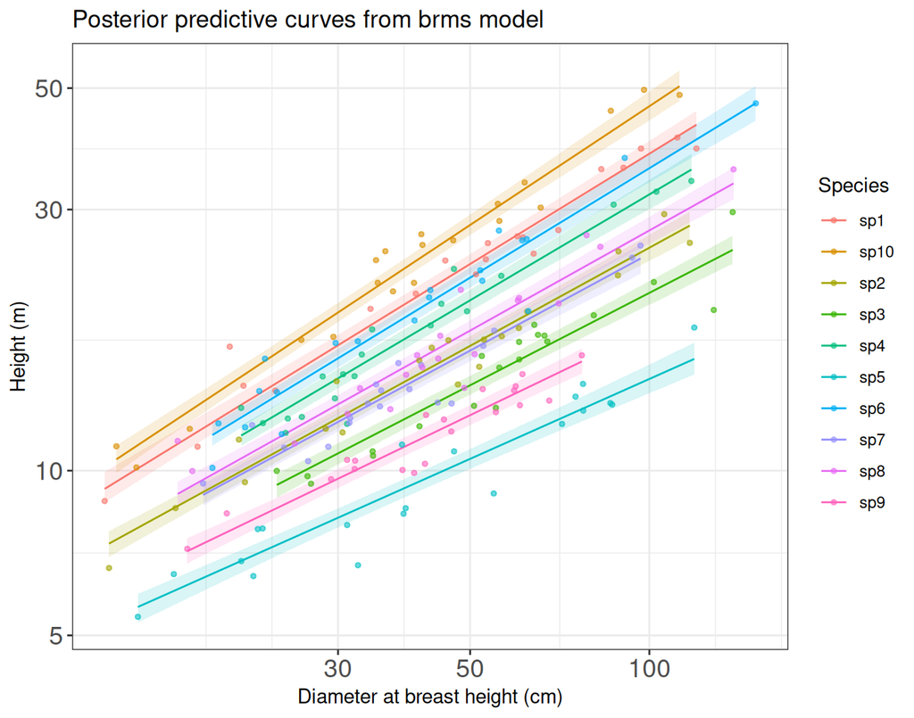

```r
pred_brm_summary <- fitted(
  slope_fit_brm,
  newdata = pred_grid,
  re_formula = NULL
) |>
  tibble::as_tibble() |>
  dplyr::bind_cols(pred_grid) |>
  dplyr::mutate(
    estimate = exp(Estimate),
    lower = exp(Q2.5),
    upper = exp(Q97.5)
  )

ggplot(pred_brm_summary, aes(dbh, estimate, colour = sp)) +
  geom_ribbon(
    aes(ymin = lower, ymax = upper, fill = sp),
    alpha = 0.15,
    colour = NA
  ) +
  geom_line() +
  geom_point(
    data = allo_df,
    aes(dbh, h, colour = sp),
    size = 1,
    alpha = 0.6,
    inherit.aes = FALSE
  ) +
  scale_x_log10() +
  scale_y_log10() +
  guides(fill = "none", colour = guide_legend(title = "Species")) +
  labs(
    x = "Diameter at breast height (cm)",
    y = "Height (m)",
    title = "Posterior predictive curves from brms model"
  )
```

# 10 Varying slopes and intercepts, and group-level predictors

**H:** There is a power-law relationship ($y =\beta_0 x^{\beta_1}$) between tree diameter (DBH) and tree maximum height, and both the scaling factor $\beta_0$ and the exponent $\beta_1$ vary among species. Those species-level variations can be explained by wood density (group-level predictor: $u$) of each species.

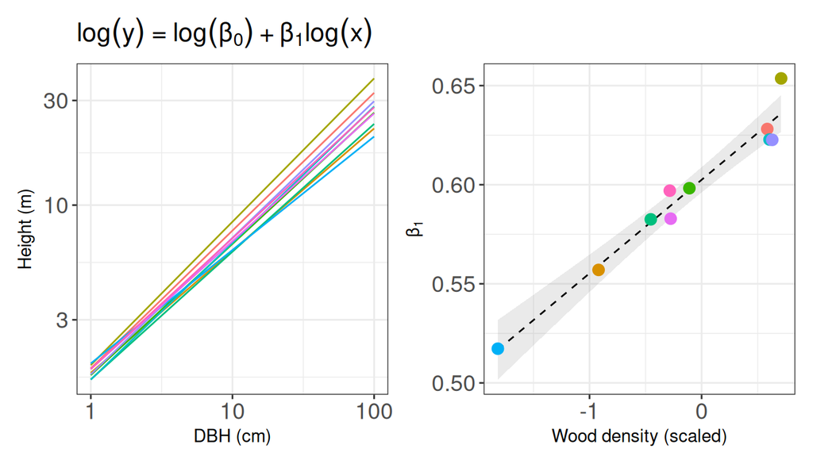

$$\text{log}\; y_{ij} \sim N(\text{log}\; \beta_{0j} + \beta_{1j} x_{ij}, \sigma)$$

$$\begin{bmatrix}
\text{log}\; \beta_{0j} \\
\beta_{1j}
\end{bmatrix}
\sim
\mathrm{MVN}
\Biggl(
\underbrace{
\boldsymbol{\mu} =
\begin{bmatrix}
\gamma_{0}^{(\beta_0)} + \gamma_{1}^{(\beta_0)}u_{j} \\
\gamma_{0}^{(\beta_1)} + \gamma_{1}^{(\beta_1)}u_{j}
\end{bmatrix}}_{\text{mean depends on }u_j},
\boldsymbol{\Sigma} =
\begin{bmatrix}
\sigma_{0}^2 & \rho \sigma_{0} \sigma_{1} \\
\rho \sigma_{0} \sigma_{1} & \sigma_{1}^2
\end{bmatrix}
\Biggr)$$

**Q:** What are the coefficients for species-level regressions ($\gamma_{0}^{(\beta_0)}$, $\gamma_{1}^{(\beta_0}$, $\gamma_{0}^{(\beta_1)}$, and $\gamma_{1}^{(\beta_1}$)?

## 10.1 CmdStan

```r
allo_vslope_list$L <- 2

allo_vslope_list$u <- rbind(
  rep(1, allo_vslope_list$J),
  trait
)
str(allo_vslope_list)
```

```
List of 8
 $ y : num [1:200] 3.29 3.66 3.7 3.58 3.19 ...
 $ x : num [1:200, 1:2] 1 1 1 1 1 1 1 1 1 1 ...
 $ jj: int [1:200] 1 1 1 1 1 1 1 1 1 1 ...
 $ N : int 200
 $ K : num 2
 $ J : int 10
 $ L : num 2
 $ u : num [1:2, 1:10] 1 0.586 1 0.709 1 ...
  ..- attr(*, "dimnames")=List of 2
  .. ..$ : chr [1:2] "" "trait"
  .. ..$ : NULL
```

```r
vgrp_fit <- vslope_mod$sample(
  data = allo_vslope_list,
  seed = 1234,
  chains = 4,
  parallel_chains = 4,
  iter_warmup = 1000, # number of warmup iterations
  iter_sampling = 1000, # number of sampling iterations
  adapt_delta = 0.95, # increase adapt_delta to avoid divergent transitions
  max_treedepth = 15, # increase max_treedepth to avoid max treedepth errors
  refresh = 0 # don't print update
)
```

```
Running MCMC with 4 parallel chains...
```

[output not shown]

[output not shown]

[output not shown]

[output not shown]

[output not shown]

[output not shown]

[output not shown]

[output not shown]

[output not shown]

[output not shown]

[output not shown]

[output not shown]

[output not shown]

[output not shown]

[output not shown]

[output not shown]

[output not shown]

[output not shown]

[output not shown]

[output not shown]

[output not shown]

[output not shown]

[output not shown]

[output not shown]

[output not shown]

[output not shown]

[output not shown]

[output not shown]

[output not shown]

[output not shown]

[output not shown]

[output not shown]

[output not shown]

[output not shown]

[output not shown]

[output not shown]

[output not shown]

[output not shown]

[output not shown]

[output not shown]

[output not shown]

[output not shown]

[output not shown]

[output not shown]

[output not shown]

[output not shown]

[output not shown]

[output not shown]

[output not shown]

[output not shown]

[output not shown]

[output not shown]

[output not shown]

[output not shown]

[output not shown]

[output not shown]

[output not shown]

[output not shown]

[output not shown]

[output not shown]

[output not shown]

[output not shown]

[output not shown]

[output not shown]

[output not shown]

[output not shown]

[output not shown]

[output not shown]

[output not shown]

[output not shown]

[output not shown]

[output not shown]

[output not shown]

[output not shown]

[output not shown]

[output not shown]

[output not shown]

[output not shown]

[output not shown]

[output not shown]

[output not shown]

[output not shown]

[output not shown]

[output not shown]

[output not shown]

[output not shown]

[output not shown]

[output not shown]

[output not shown]

[output not shown]

[output not shown]

[output not shown]

[output not shown]

[output not shown]

[output not shown]

[output not shown]

[output not shown]

[output not shown]

[output not shown]

[output not shown]

[output not shown]

[output not shown]

[output not shown]

[output not shown]

[output not shown]

[output not shown]

[output not shown]

[output not shown]

[output not shown]

[output not shown]

[output not shown]

[output not shown]

[output not shown]

[output not shown]

[output not shown]

[output not shown]

[output not shown]

[output not shown]

[output not shown]

[output not shown]

[output not shown]

[output not shown]

[output not shown]

[output not shown]

[output not shown]

[output not shown]

[output not shown]

[output not shown]

[output not shown]

[output not shown]

[output not shown]

[output not shown]

[output not shown]

[output not shown]

[output not shown]

[output not shown]

[output not shown]

[output not shown]

[output not shown]

[output not shown]

[output not shown]

[output not shown]

[output not shown]

[output not shown]

[output not shown]

[output not shown]

[output not shown]

[output not shown]

[output not shown]

[output not shown]

[output not shown]

[output not shown]

[output not shown]

[output not shown]

[output not shown]

```
Chain 4 finished in 6.3 seconds.
Chain 1 finished in 6.7 seconds.
Chain 3 finished in 6.7 seconds.
Chain 2 finished in 7.6 seconds.

All 4 chains finished successfully.
Mean chain execution time: 6.8 seconds.
Total execution time: 7.6 seconds.
```

```r
my_summary(vgrp_fit$draws())
```

```
# A tibble: 52 × 10
   variable      mean      sd     q2.5       q5      q25     q50     q75     q95
   <chr>        <dbl>   <dbl>    <dbl>    <dbl>    <dbl>   <dbl>   <dbl>   <dbl>
 1 lp__       3.58e+2 4.48     3.48e+2  3.50e+2  3.55e+2 3.58e+2 3.61e+2 3.65e+2
 2 gamma[1,1] 5.02e-1 0.0551   3.91e-1  4.14e-1  4.66e-1 5.02e-1 5.39e-1 5.92e-1
 3 gamma[2,1] 6.18e-1 0.0154   5.87e-1  5.93e-1  6.08e-1 6.18e-1 6.28e-1 6.43e-1
 4 gamma[1,2] 4.35e-2 0.0660  -8.68e-2 -6.03e-2  4.12e-4 4.31e-2 8.54e-2 1.54e-1
 5 gamma[2,2] 8.01e-2 0.0190   4.29e-2  4.89e-2  6.79e-2 8.04e-2 9.24e-2 1.11e-1
 6 sigma      9.26e-2 0.00476  8.37e-2  8.51e-2  8.94e-2 9.24e-2 9.56e-2 1.01e-1
 7 tau[1]     6.70e-2 0.0486   2.96e-3  5.76e-3  2.92e-2 6.04e-2 9.40e-2 1.55e-1
 8 tau[2]     2.39e-2 0.0131   1.81e-3  3.96e-3  1.55e-2 2.28e-2 3.07e-2 4.66e-2
 9 z[1,1]     4.33e-1 0.809   -1.27e+0 -9.48e-1 -5.01e-2 4.40e-1 9.42e-1 1.75e+0
10 z[2,1]     1.46e-1 0.756   -1.45e+0 -1.18e+0 -3.06e-1 1.65e-1 6.41e-1 1.32e+0
# ℹ 42 more rows
# ℹ 1 more variable: q97.5 <dbl>
```

```r
vgrp_fit$diagnostic_summary()
```

```
$num_divergent
[1] 0 0 0 0

$num_max_treedepth
[1] 0 0 0 0

$ebfmi
[1] 0.7879778 0.8287131 0.8046688 0.7915153
```

## 10.2 brms

```r
priors <- c(
  prior(normal(0, 2.5), class = Intercept),
  prior(normal(0, 2.5), class = b),
  prior(lkj(2), class = cor),                # Ω ~ LKJ(2)
  prior(cauchy(0, 2.5), class = sigma)
)
vgrp_fit_brm <- brm(
  log(h) ~ log(dbh) * wd + (1 + log(dbh) | sp),
  family = gaussian(),
  data = allo_df,
  prior = priors,
  refresh = 0, # don't print update
  seed = 1234,
  chains = 4, cores = 4,
  control = list(
    adapt_delta  = 0.95,  # default is 0.8
    max_treedepth = 15    # default is 10
  ),
  backend = "cmdstanr"
)
```

```
Running MCMC with 4 parallel chains...

Chain 1 finished in 6.2 seconds.
Chain 4 finished in 6.7 seconds.
Chain 3 finished in 6.8 seconds.
Chain 2 finished in 7.3 seconds.

All 4 chains finished successfully.
Mean chain execution time: 6.7 seconds.
Total execution time: 7.3 seconds.
```

```r
summary(vgrp_fit_brm)
```

```
 Family: gaussian
  Links: mu = identity
Formula: log(h) ~ log(dbh) * wd + (1 + log(dbh) | sp)
   Data: allo_df (Number of observations: 200)
  Draws: 4 chains, each with iter = 2000; warmup = 1000; thin = 1;
         total post-warmup draws = 4000

Multilevel Hyperparameters:
~sp (Number of levels: 10)
                      Estimate Est.Error l-95% CI u-95% CI Rhat Bulk_ESS
sd(Intercept)             0.09      0.07     0.00     0.25 1.00     1710
sd(logdbh)                0.08      0.03     0.04     0.15 1.00     1533
cor(Intercept,logdbh)     0.15      0.43    -0.72     0.85 1.00     1018
                      Tail_ESS
sd(Intercept)             1911
sd(logdbh)                2119
cor(Intercept,logdbh)     1332

Regression Coefficients:
          Estimate Est.Error l-95% CI u-95% CI Rhat Bulk_ESS Tail_ESS
Intercept     0.50      0.06     0.39     0.62 1.00     3881     2832
logdbh        0.60      0.03     0.54     0.66 1.00     1778     2069
wd            0.02      0.07    -0.12     0.17 1.00     3192     2064
logdbh:wd    -0.05      0.04    -0.13     0.02 1.00     2444     2240

Further Distributional Parameters:
      Estimate Est.Error l-95% CI u-95% CI Rhat Bulk_ESS Tail_ESS
sigma     0.09      0.00     0.08     0.10 1.00     5598     3118

Draws were sampled using sample(hmc). For each parameter, Bulk_ESS
and Tail_ESS are effective sample size measures, and Rhat is the potential
scale reduction factor on split chains (at convergence, Rhat = 1).
```

## 10.3 lme4

```r
grp_fit_lme <- lme4::lmer(
  log(h) ~ log(dbh) * wd + (1 + log(dbh) | sp),
  data = allo_df)
```

```
boundary (singular) fit: see help('isSingular')
```

**Not convergent!** It’s hard to fit this kind of complex multilevel model with MLE framework like `lme4`.

# 11 References

- Betancourt, M. (2017). [Diagnosing Biased Inference with Divergences](https://betanalpha.github.io/assets/case_studies/divergences_and_bias.html#3_a_non-centered_eight_schools_implementation).
- [Gelman, A. et al. Bayesian Data Analysis, Third Edition. (Chapman & Hall/CRC, 2013)](http://www.stat.columbia.edu/~gelman/book/)
- [Stan User’s Guide](https://mc-stan.org/docs/stan-users-guide/index.html)
- [Stan Functions Reference](https://mc-stan.org/docs/functions-reference/index.html)